# CSE 5243 - Introduction to Data Mining

# Section: 3 - Evaluate the **K-Means** Algorithm on the **Large2** Dataset

## Section: 3.1 - Calculate True Cluster Measures

- Given that you know the true clusters (from column y in the original data), compute the true within-cluster WSS (also called “SSE” in the slides), the between-cluster BSS, and the Total SSE (WSS+BSS).

```python
# Load the data
data = pd.read_csv('large2_Xydf.csv')

X = data[['X0', 'X1']].values
true_labels = data['y'].values

WSS, BSS, total_SSE = calculate_true_clusters(X, true_labels)
print(f"True WSS: {round(WSS, 4)}\nTrue BSS: {round(BSS, 4)}\nTotal SSE: {round(total_SSE, 4)}")
```

```
True WSS: 1917.7276
True BSS: 1219.5688
Total SSE: 3137.2964
```

## Section: 3.2 - Configure and Run the SciKitLearn K-Means Algorithm

- Explain all configuration parameter values you chose, and why you chose them.
- Run your algorithm for K=2, 3, 4.
- For each run, compute the WSS, BSS, and Total SSE (WSS+BSS), and compute the running time (see Python Time reference – see %%time, time.process_time(), etc.).

```python
# Run K-means for K=2, 3, 4
results = {}
for K in [2, 3, 4]:
    WSS, BSS, total_SSE, execution_time = kmeans_clustering(X, K)
    results[K] = {'WSS': round(WSS, 4), 'BSS': round(BSS, 4), 'Total SSE': round(total_SSE, 4), 'Execution Time': round(execution_time, 4)}

for key, value in results.items():
    print("For K value =", key, ":", value)
```

```
For K value = 2 : {'WSS': 1310.2119, 'BSS': 1827.0845, 'Total SSE': 3137.2964, 'Execution Time': 0.075}
For K value = 3 : {'WSS': 880.3637, 'BSS': 2256.9328, 'Total SSE': 3137.2964, 'Execution Time': 0.153}
For K value = 4 : {'WSS': 592.6597, 'BSS': 2544.6368, 'Total SSE': 3137.2964, 'Execution Time': 0.15}
```

## Section: 3.3 - For the K=2 Case Above:

- Create a scatterplot, overlaying the true cluster with the cluster produced by your algorithm. (Or alternatively, create two side by side scatterplots).
- Create a cross tabulation matrix (i.e., confusion matrix) comparing the true and assigned clusters, and the basic measures (precision, recall, F1, accuracy, etc. - see classification_report). Note that you may need to "match up" the true and assigned cluster labels. See the linear-sum-assignment and Hungarian algorithm references, for example.

```python
# Get predicted labels for K=2
K = 2
kmeans = KMeans(n_clusters=K, init='k-means++', max_iter=300, random_state=42)
kmeans.fit(X)
predicted_labels = kmeans.labels_

# Match predicted labels to true labels
matched_labels = match_labels(true_labels, predicted_labels, K)
```

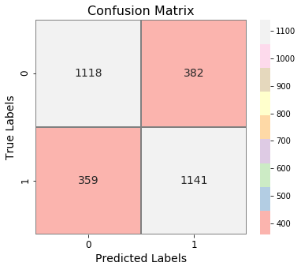

```python
# Confusion matrix
cm = confusion_matrix(true_labels, matched_labels)

# Create the heatmap
plt.figure(figsize=(6, 5))
sns.heatmap(
    cm,
    annot=True,
    fmt='d',
    cmap='Pastel1',
    linewidths=0.3,
    linecolor='gray',
    annot_kws={"size": 14}
)
plt.title('Confusion Matrix', fontsize=16)
plt.xlabel('Predicted Labels', fontsize=14)
plt.ylabel('True Labels', fontsize=14)
plt.xticks(fontsize=12)
plt.yticks(fontsize=12)
plt.show()
```

```python
# Classification report
report = classification_report(true_labels, matched_labels, output_dict=True)

report_df = pd.DataFrame(report).transpose()

# Display the report
print("Classification Report:")
report_df
```

```
Classification Report:
```

|  | precision | recall | f1-score | support |
| --- | --- | --- | --- | --- |
| 0 | 0.756940 | 0.745333 | 0.751092 | 1500.000 |
| 1 | 0.749179 | 0.760667 | 0.754879 | 1500.000 |
| accuracy | 0.753000 | 0.753000 | 0.753000 | 0.753 |
| macro avg | 0.753059 | 0.753000 | 0.752985 | 3000.000 |
| weighted avg | 0.753059 | 0.753000 | 0.752985 | 3000.000 |

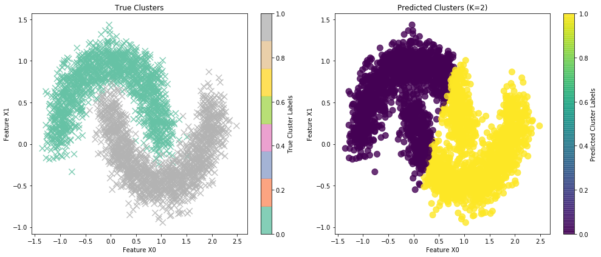

```python
# Enhanced side-by-side scatter plot with better visuals
plt.figure(figsize=(14, 6))

# Plot for true clusters
plt.subplot(1, 2, 1)
scatter_true = plt.scatter(X[:, 0], X[:, 1], c=true_labels, cmap='Set2', marker='x', alpha=0.8, s=100)
plt.title('True Clusters')
plt.xlabel('Feature X0')
plt.ylabel('Feature X1')
plt.colorbar(scatter_true, label='True Cluster Labels')

# Plot for predicted clusters
plt.subplot(1, 2, 2)
scatter_pred = plt.scatter(X[:, 0], X[:, 1], c=matched_labels, cmap='viridis', marker='o', alpha=0.8, s=100)
plt.title('Predicted Clusters (K=2)')
plt.xlabel('Feature X0')
plt.ylabel('Feature X1')
plt.colorbar(scatter_pred, label='Predicted Cluster Labels')

plt.tight_layout()
plt.show()
```